# Projeto2

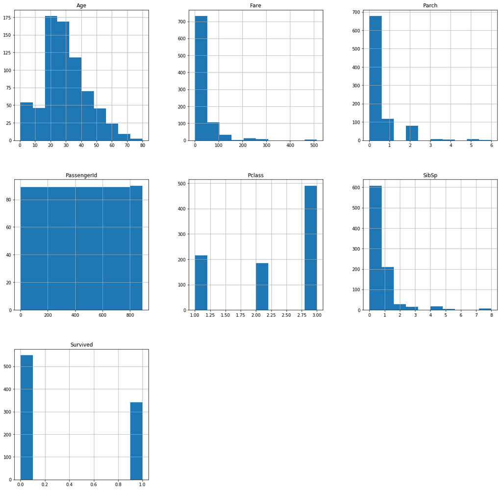

```python
# Obtendo uma visão geral dos passageiros por meio de histogramas
df.hist(figsize=(20,20));
```

```python
# Percebemos que grande parte dos dados de Idade demonstram que grande parte dos integrantes têm idades variando de
# 16 a 32 anos
# A maior parte das tarifas tinham valores baixos.
# A maior parte dos passageiros não possuíam pais / filhos a bordo
# Das três classes presentes no navio percebemos que existe uma concentração de passageiros na 3ª classe.
```

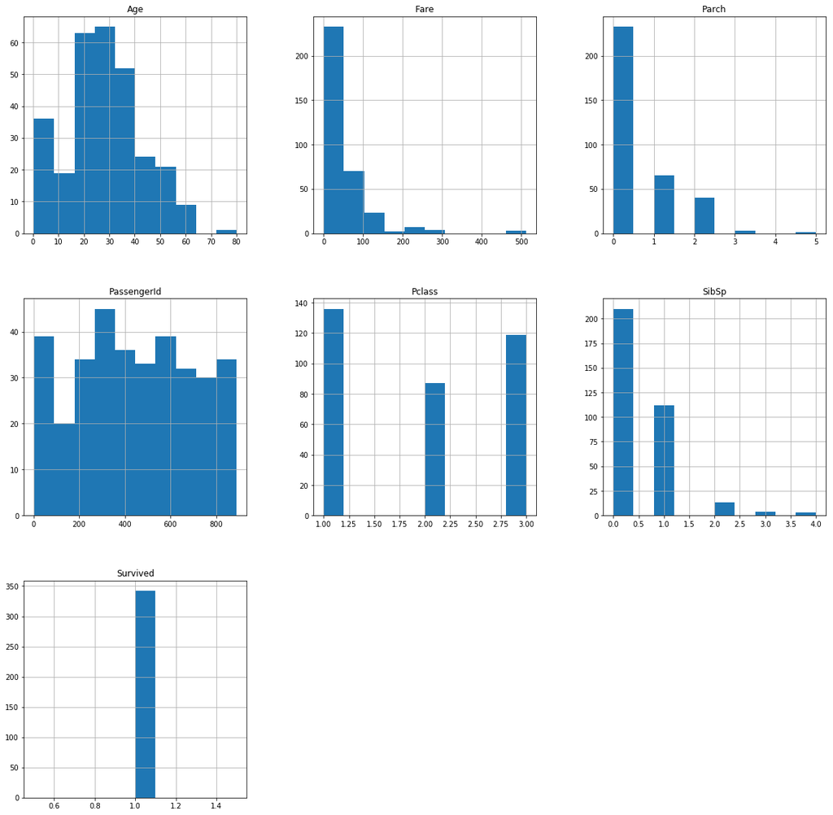

```python
# Obtendo uma visão geral dos sobreviventes por meio de histogramas
df_s.hist(figsize=(20,20));
```

```python
# Sobreviventes
# Percebemos que o perfil de idades dos sobreviventes se assemelha ao dos passageiros
# Percebemos que as tarifas pagas pelos sobreviventes têm valores baixos, ou seja, parece com as tarifas pagas pelos passageiros.
# A maior parte dos passageiros não possuíam pais / filhos a bordo
# IMPORTANTE: Apesar de grande parcela dos passageiros habitarem a 3ª classe, percentualmente poucos passageiros sobreviveram.
```

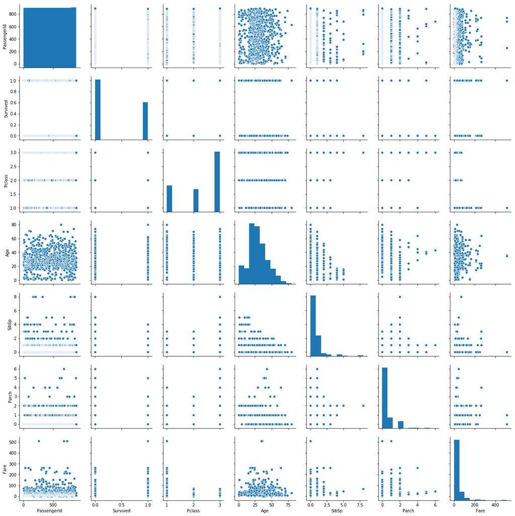

```python
# Visualização geral dos passageiros por meio de gráficos de dispersões e histogramas
sns.pairplot(df);
```

```python
# Vemos que as maioria das passagens tiveram valores mais baixos
# Ocupantes da primeira classe têm valores de passagem variando de baixo até alto.
```

```python
# Classes do navio
Classes = [1,2,3]

# Ocupantes por classe
QtdClass = []
for item in Classes:
    data = df[(df['Pclass'] == item)].count()['Survived']
    QtdClass.append(data)
    item+=1

# Sobreviventes por classe
QtdSuvClass = []
PerSuv = [] # Percentual de Sobreviventes por classe

for item in Classes:
    data = df[(df['Pclass'] == item)&
              (df['Survived'] == 1)].count()['Survived']
    QtdSuvClass.append(data)

item = 0 # index
while item < len(Classes):
    print('A QTD de pass. na {}º clas. era {}, sendo {}% do total de pass., e sobrev. {} pessoas, que corresponde a {}% da classe.'.format
          (Classes[item],
           QtdClass[item],
           round((QtdClass[item]/Passengers)*100 , 2),
           QtdSuvClass[item],
           round((QtdSuvClass[item]/QtdClass[item])*100,2) ))
    PerSuv.append(round( (QtdSuvClass[item]/QtdClass[item])*100,2))
    item+=1
```

```
A QTD de pass. na 1º clas. era 216, sendo 24.24% do total de pass., e sobrev. 136 pessoas, que corresponde a 62.96% da classe.
A QTD de pass. na 2º clas. era 184, sendo 20.65% do total de pass., e sobrev. 87 pessoas, que corresponde a 47.28% da classe.
A QTD de pass. na 3º clas. era 491, sendo 55.11% do total de pass., e sobrev. 119 pessoas, que corresponde a 24.24% da classe.
```

```python
# Percebemos que a classe habitada pelos passageiros foi um critério relevante para garantir a sobrevivência.
# Assim, podemos dizer que quanto mais 'alta' a classe maior seria a chance de sobreviver.
```

```python
# Número de sobreviventes e não sobreviventes
NSurvived = df[df['Survived'] == 1].sum()['Survived']
NNSurvived = df[df['Survived'] == 0].sum()['Survived']
```

```python
print('O número de sobreviventes foi de:', NSurvived ,'de um número de', Passengers ,'passageiros',
      'que corresponde a',  round ( (NSurvived/ Passengers)*100 , 2),'%.')
```

```
O número de sobreviventes foi de: 342 de um número de 891 passageiros que corresponde a 38.38 %.
```

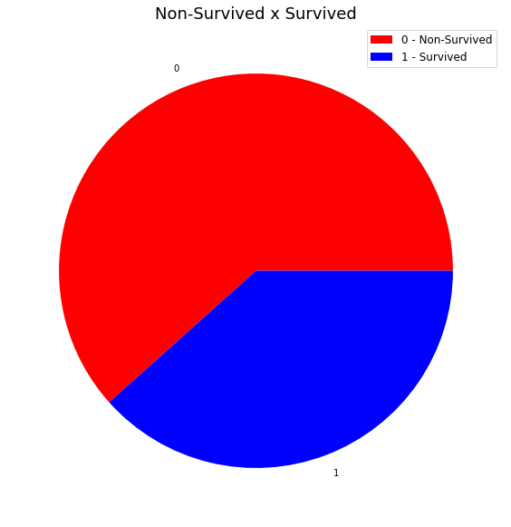

```python
# Gráfico de Pizza de Sobreviventes e Não Sobreviventes
df.groupby(['Survived'],as_index= False).count()['PassengerId'].plot(kind='pie' ,colors =['red','blue'], figsize=(10,10));
plt.title('Non-Survived x Survived', fontsize=18)
plt.ylabel('', fontsize=18);
plt.legend(['0 - Non-Survived','1 - Survived'], fontsize=12);
```

```python
# A divisão de passageiros entre homens e mulheres.
NMale = df[df['Sex'] == 'male'].count()['Sex']
NFemale = df[df['Sex'] == 'female'].count()['Sex']
print('O número total de passageiros é de', Passengers ,', sendo',NMale, 'homens que correspondem a',
      round((NMale/Passengers)*100,2) ,'%.', 'O número de mulheres é de' ,NFemale, '-',
      round((NFemale/Passengers)*100,2) ,'%.')
```

```
O número total de passageiros é de 891 , sendo 577 homens que correspondem a 64.76 %. O número de mulheres é de 314 - 35.24 %.
```

```python
# Agrupando os dados por Sobreviventes e Sexo.
df.groupby(['Survived', 'Sex'],as_index= False).count()
```

|  | Survived | Sex | PassengerId | Pclass | Name | Age | SibSp | Parch | Ticket | Fare | Cabin | Embarked |
| --- | --- | --- | --- | --- | --- | --- | --- | --- | --- | --- | --- | --- |
| 0 | 0 | female | 81 | 81 | 81 | 64 | 81 | 81 | 81 | 81 | 6 | 81 |
| 1 | 0 | male | 468 | 468 | 468 | 360 | 468 | 468 | 468 | 468 | 62 | 468 |
| 2 | 1 | female | 233 | 233 | 233 | 197 | 233 | 233 | 233 | 233 | 91 | 231 |
| 3 | 1 | male | 109 | 109 | 109 | 93 | 109 | 109 | 109 | 109 | 45 | 109 |

```python
# A divisão de sobreviventes entre homens e mulheres.

NMales = df_s[df_s['Sex'] == 'male'].count()['Sex']
NFemales = df_s[df_s['Sex'] == 'female'].count()['Sex']
print('O número de sobreviventes foi de', NSurvived ,', sendo',NMales, 'homens que correspondem a',
      round((NMales/NSurvived)*100,2) ,'%.',
      'O número de mulheres é de' ,NFemales, '-',
      round((NFemales/NSurvived)*100,2) ,'%.',
     'O nº corresponde a', round((NSurvived/Passengers)*100 , 2), '% dos passageiros.')
```

```
O número de sobreviventes foi de 342 , sendo 109 homens que correspondem a 31.87 %. O número de mulheres é de 233 - 68.13 %. O nº corresponde a 38.38 % dos passageiros.
```

### Percebemos que uma parcela significativa dos sobreviventes eram mulheres, mesmo elas sendo a minoria entre os passageiros

```python
# Agrupando os dados por Sexo, Sobreviventes, Classe
df.groupby(['Survived', 'Sex', 'Pclass'],as_index= False).count()
```

|  | Survived | Sex | Pclass | PassengerId | Name | Age | SibSp | Parch | Ticket | Fare | Cabin | Embarked |
| --- | --- | --- | --- | --- | --- | --- | --- | --- | --- | --- | --- | --- |
| 0 | 0 | female | 1 | 3 | 3 | 3 | 3 | 3 | 3 | 3 | 3 | 3 |
| 1 | 0 | female | 2 | 6 | 6 | 6 | 6 | 6 | 6 | 6 | 1 | 6 |
| 2 | 0 | female | 3 | 72 | 72 | 55 | 72 | 72 | 72 | 72 | 2 | 72 |
| 3 | 0 | male | 1 | 77 | 77 | 61 | 77 | 77 | 77 | 77 | 56 | 77 |
| 4 | 0 | male | 2 | 91 | 91 | 84 | 91 | 91 | 91 | 91 | 2 | 91 |
| 5 | 0 | male | 3 | 300 | 300 | 215 | 300 | 300 | 300 | 300 | 4 | 300 |
| 6 | 1 | female | 1 | 91 | 91 | 82 | 91 | 91 | 91 | 91 | 78 | 89 |
| 7 | 1 | female | 2 | 70 | 70 | 68 | 70 | 70 | 70 | 70 | 9 | 70 |
| 8 | 1 | female | 3 | 72 | 72 | 47 | 72 | 72 | 72 | 72 | 4 | 72 |
| 9 | 1 | male | 1 | 45 | 45 | 40 | 45 | 45 | 45 | 45 | 39 | 45 |
| 10 | 1 | male | 2 | 17 | 17 | 15 | 17 | 17 | 17 | 17 | 4 | 17 |
| 11 | 1 | male | 3 | 47 | 47 | 38 | 47 | 47 | 47 | 47 | 2 | 47 |

```python
# Agrupando os dados por Sexo, Sobrevivente e Classe
df.groupby(['Sex', 'Pclass'],as_index= False).count()
```

|  | Sex | Pclass | PassengerId | Survived | Name | Age | SibSp | Parch | Ticket | Fare | Cabin | Embarked |
| --- | --- | --- | --- | --- | --- | --- | --- | --- | --- | --- | --- | --- |
| 0 | female | 1 | 94 | 94 | 94 | 85 | 94 | 94 | 94 | 94 | 81 | 92 |
| 1 | female | 2 | 76 | 76 | 76 | 74 | 76 | 76 | 76 | 76 | 10 | 76 |
| 2 | female | 3 | 144 | 144 | 144 | 102 | 144 | 144 | 144 | 144 | 6 | 144 |
| 3 | male | 1 | 122 | 122 | 122 | 101 | 122 | 122 | 122 | 122 | 95 | 122 |
| 4 | male | 2 | 108 | 108 | 108 | 99 | 108 | 108 | 108 | 108 | 6 | 108 |
| 5 | male | 3 | 347 | 347 | 347 | 253 | 347 | 347 | 347 | 347 | 6 | 347 |

```python
# Estratificando ainda mais os dados percebemos que a classe habitada pelos passageiros influenciou na sobrevivência, quase
# todas as mulheres sobreviveram, exceto as ocupantes de 3ª classse.

# Quantidade de Mulheres por Classe
QtdFemaleClass = []
for item in Classes:
    data = (df[(df['Sex'] == 'female')&
          (df['Pclass'] == item)].count()['Survived'])
    QtdFemaleClass.append(data)

# Quantidade de Mulheres Sobreviventes por Classe
QtdSuvFemaleClass = []
for item in Classes:
    data = df_s[(df_s['Sex']=='female')&
     (df_s['Survived']==1)&
    (df_s['Pclass'] == item)].count()['Survived']
    QtdSuvFemaleClass.append(data)
```

```python
# O percentual de Mulheres Sobreviventes por Classe
item = 0
PerSuvFemale = []
while item < len(Classes):
    print('A quantidade de mulheres na {}º classe era de {} passageiros sobrevivendo {} pessoas, {}%'.format
          (Classes[item], QtdFemaleClass[item] ,
           QtdSuvFemaleClass[item] ,
           round((QtdSuvFemaleClass[item]/QtdFemaleClass[item])*100,2) ))
    PerSuvFemale.append(round((QtdSuvFemaleClass[item]/QtdFemaleClass[item])*100,2))
    item+=1
```

```
A quantidade de mulheres na 1º classe era de 94 passageiros sobrevivendo 91 pessoas, 96.81%
A quantidade de mulheres na 2º classe era de 76 passageiros sobrevivendo 70 pessoas, 92.11%
A quantidade de mulheres na 3º classe era de 144 passageiros sobrevivendo 72 pessoas, 50.0%
```

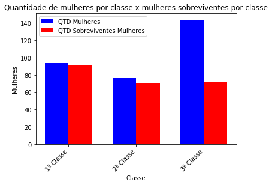

```python
# Gráfico de barras com valores múltiplos
# Quantidade de mulheres por classe x mulheres sobreviventes por classe

categoria = ['1ª Classe', '2ª Classe', '3ª Classe']

pos = np.arange(3) # posições das barras
tam = .35 # distancia das barras.

fig, ax = plt.subplots() # para plotar vários gráficos em uma mesma figura.
# Ambos os plots seguem a mesma ideia, a posição da barra é dada pelo primeiro
# argumento:
# - para a barra ficar a esquerda do centro do tick em x
# + para a barra ficar a direita do centro do tick em x.
plt1 = ax.bar(pos-tam/2, QtdFemaleClass, tam, color='blue', label='QTD Mulheres')
plt2 = ax.bar(pos+tam/2, QtdSuvFemaleClass, tam, color='red', label='QTD Sobreviventes Mulheres')

# Quando se usa axes você deve usar a axe criada para adicionar titulos e rótulos.
ax.set_title('Quantidade de mulheres por classe x mulheres sobreviventes por classe')
ax.set_xlabel('Classe')
ax.set_ylabel('Mulheres')

# Define as posições dos ticks, pos é um array da seguinte forma [0, 1, 2]
ax.set_xticks(pos)
# rotation faz o angulo do texto girar em graism e ha diz qual ponto deve ser
# alinhado o texto
ax.set_xticklabels(categoria, rotation=45, ha='right')
ax.legend(); # legend faz os labels se tornarem labels de legendas na figura.
# Ponto e vírgula remove alguns dados de objeto que apareceriam normalmente
# caso não o adiciona-se
```

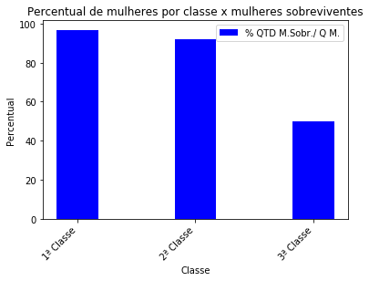

```python
# Gráfico de barras com valores múltiplos
# Percentual de mulheres sobreviventes por classe x mulheres sobreviventes
categoria = ['1ª Classe', '2ª Classe', '3ª Classe']

pos = np.arange(3) # posições das barras
tam = .35 # distancia das barras.

fig, ax = plt.subplots() # para plotar vários gráficos em uma mesma figura.
# Ambos os plots seguem a mesma ideia, a posição da barra é dada pelo primeiro
# argumento:
plt3 = ax.bar(pos, PerSuvFemale, tam, color='blue', label='% QTD M.Sobr./ Q M.')

# Quando se usa axes você deve usar a axe criada para adicionar titulos e rótulos.
ax.set_title('Percentual de mulheres por classe x mulheres sobreviventes')
ax.set_xlabel('Classe')
ax.set_ylabel('Percentual')

# Define as posições dos ticks, pos é um array da seguinte forma [0, 1, 2]
ax.set_xticks(pos)
# rotation faz o angulo do texto girar em graism e ha diz qual ponto deve ser
# alinhado o texto
ax.set_xticklabels(categoria, rotation=45, ha='right')
ax.legend(); # legend faz os labels se tornarem labels de legendas na figura.
# Ponto e vírgula remove alguns dados de objeto que apareceriam normalmente
# caso não o adiciona-se
```

```python
# Observando os gráficos acima percebemos:
# No primeiro Quantidade de mulheres por classe x mulheres sobreviventes por classe, verificamos
# duas barras por comparando os sobreviventes por classe, no segundo é possível identificar o
# percentual sobreviventes.
```

```python
# Quantidade de Homens por Classe
QtdMaleClass = []
for item in Classes:
    data = (df[(df['Sex'] == 'male')&
          (df['Pclass'] == item)].count()['Survived'])
    QtdMaleClass.append(data)

# Quantidade de Homens Sobreviventes por Classe
QtdSuvMaleClass = []
for item in Classes:
    data = df_s[(df_s['Sex']=='male')&
     (df_s['Survived']==1)&
    (df_s['Pclass'] == item)].count()['Survived']
    QtdSuvMaleClass.append(data)
```

```python
# O percentual de Homens Sobreviventes por Classe
item = 0
PerSuvMale = []
while item < len(Classes):
    print('A quantidade de homens na {}º classe era de {} passageiros sobrevivendo {} pessoas, {}%'.format
          (Classes[item], QtdMaleClass[item] ,
           QtdSuvMaleClass[item] ,
           round((QtdSuvMaleClass[item]/QtdMaleClass[item])*100,2) ))
    PerSuvMale.append(round((QtdSuvMaleClass[item]/QtdMaleClass[item])*100,2))
    item+=1
```

```
A quantidade de homens na 1º classe era de 122 passageiros sobrevivendo 45 pessoas, 36.89%
A quantidade de homens na 2º classe era de 108 passageiros sobrevivendo 17 pessoas, 15.74%
A quantidade de homens na 3º classe era de 347 passageiros sobrevivendo 47 pessoas, 13.54%
```

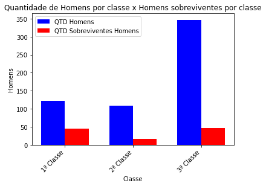

```python
# Gráfico de barras com valores múltiplos
# Quantidade de homens por classe x homens sobreviventes por classe

categoria = ['1ª Classe', '2ª Classe', '3ª Classe']

pos = np.arange(3) # posições das barras
tam = .35 # distancia das barras.

fig, ax = plt.subplots() # para plotar vários gráficos em uma mesma figura.
# Ambos os plots seguem a mesma ideia, a posição da barra é dada pelo primeiro
# argumento:
# - para a barra ficar a esquerda do centro do tick em x
# + para a barra ficar a direita do centro do tick em x.
plt1 = ax.bar(pos-tam/2, QtdMaleClass, tam, color='blue', label='QTD Homens')
plt2 = ax.bar(pos+tam/2, QtdSuvMaleClass, tam, color='red', label='QTD Sobreviventes Homens')

# Quando se usa axes você deve usar a axe criada para adicionar titulos e rótulos.
ax.set_title('Quantidade de Homens por classe x Homens sobreviventes por classe')
ax.set_xlabel('Classe')
ax.set_ylabel('Homens')

# Define as posições dos ticks, pos é um array da seguinte forma [0, 1, 2]
ax.set_xticks(pos)
# rotation faz o angulo do texto girar em graism e ha diz qual ponto deve ser
# alinhado o texto
ax.set_xticklabels(categoria, rotation=45, ha='right')
ax.legend(); # legend faz os labels se tornarem labels de legendas na figura.
# Ponto e vírgula remove alguns dados de objeto que apareceriam normalmente
# caso não o adiciona-se
```

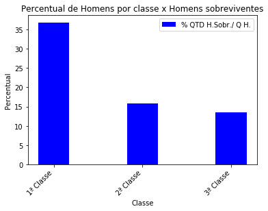

```python
# Gráfico de barras com valores múltiplos
# Percentual de Homens sobreviventes por classe x Homens sobreviventes
categoria = ['1ª Classe', '2ª Classe', '3ª Classe']

pos = np.arange(3) # posições das barras
tam = .35 # distancia das barras.

fig, ax = plt.subplots() # para plotar vários gráficos em uma mesma figura.
# Ambos os plots seguem a mesma ideia, a posição da barra é dada pelo primeiro
# argumento:
plt3 = ax.bar(pos, PerSuvMale, tam, color='blue', label='% QTD H.Sobr./ Q H.')

# Quando se usa axes você deve usar a axe criada para adicionar titulos e rótulos.
ax.set_title('Percentual de Homens por classe x Homens sobreviventes')
ax.set_xlabel('Classe')
ax.set_ylabel('Percentual')

# Define as posições dos ticks, pos é um array da seguinte forma [0, 1, 2]
ax.set_xticks(pos)
# rotation faz o angulo do texto girar em graism e ha diz qual ponto deve ser
# alinhado o texto
ax.set_xticklabels(categoria, rotation=45, ha='right')
ax.legend(); # legend faz os labels se tornarem labels de legendas na figura.
# Ponto e vírgula remove alguns dados de objeto que apareceriam normalmente
# caso não o adiciona-se
```

```python
# Agrupando pelo Local de Embarcação e por Survived
local = df.groupby(['Embarked','Survived'], as_index= False).count()
embarked = dict(df.groupby(['Embarked']).count()['PassengerId'])
embarkedSurv = dict(df_s.groupby(['Embarked']).count()['PassengerId'])
embarkedlist = []
embarkedSurvlist = []
PercEmbarkedSurvlist = []
keyembarked = (embarked.keys())
for item in keyembarked:
    embarkedlist.append(embarked[item])
    embarkedSurvlist.append(embarkedSurv[item])
    PercEmbarkedSurvlist.append( round( (embarkedSurv[item]/embarked[item])*100 , 2) )
```

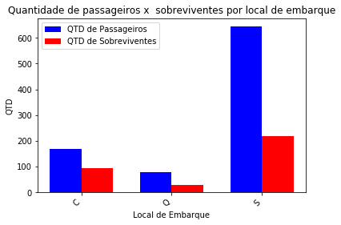

```python
# Gráfico de barras com valores multiplos
# Quantidade de passageiros x  sobreviventes por local de embarque

keyembarked = (embarked.keys())

pos = np.arange(3) # posições das barras
tam = .35 # distancia das barras.

fig, ax = plt.subplots() # para plotar vários gráficos em uma mesma figura.
# Ambos os plots seguem a mesma ideia, a posição da barra é dada pelo primeiro
# argumento:
# - para a barra ficar a esquerda do centro do tick em x
# + para a barra ficar a direita do centro do tick em x.
plt1 = ax.bar(pos-tam/2, embarkedlist, tam, color='blue', label='QTD de Passageiros')
plt2 = ax.bar(pos+tam/2, embarkedSurvlist, tam, color='red', label='QTD de Sobreviventes')

# Quando se usa axes você deve usar a axe criada para adicionar titulos e rótulos.
ax.set_title('Quantidade de passageiros x  sobreviventes por local de embarque')
ax.set_xlabel('Local de Embarque')
ax.set_ylabel('QTD')

# Define as posições dos ticks, pos é um array da seguinte forma [0, 1, 2]
ax.set_xticks(pos)
# rotation faz o angulo do texto girar em graism e ha diz qual ponto deve ser
# alinhado o texto
ax.set_xticklabels(keyembarked, rotation=45, ha='right')
ax.legend(); # legend faz os labels se tornarem labels de legendas na figura.
# Ponto e vírgula remove alguns dados de objeto que apareceriam normalmente
# caso não o adiciona-se
```

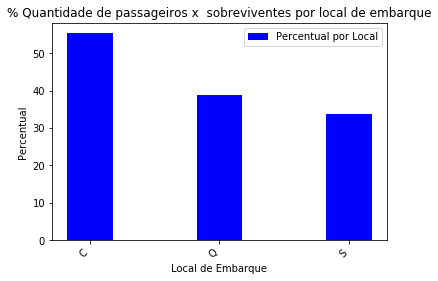

```python
# Gráfico de barras com valores multiplos
# Quantidade de passageiros x  sobreviventes por local de embarque

keyembarked = (embarked.keys())

pos = np.arange(3) # posições das barras
tam = .35 # distancia das barras.

fig, ax = plt.subplots() # para plotar vários gráficos em uma mesma figura.
# Ambos os plots seguem a mesma ideia, a posição da barra é dada pelo primeiro
# argumento:
# - para a barra ficar a esquerda do centro do tick em x
# + para a barra ficar a direita do centro do tick em x.
plt1 = ax.bar(pos, PercEmbarkedSurvlist, tam, color='blue', label='Percentual por Local')

# Quando se usa axes você deve usar a axe criada para adicionar titulos e rótulos.
ax.set_title('% Quantidade de passageiros x  sobreviventes por local de embarque')
ax.set_xlabel('Local de Embarque')
ax.set_ylabel('Percentual')

# Define as posições dos ticks, pos é um array da seguinte forma [0, 1, 2]
ax.set_xticks(pos)
# rotation faz o angulo do texto girar em graism e ha diz qual ponto deve ser
# alinhado o texto
ax.set_xticklabels(keyembarked, rotation=45, ha='right')
ax.legend(); # legend faz os labels se tornarem labels de legendas na figura.
# Ponto e vírgula remove alguns dados de objeto que apareceriam normalmente
# caso não o adiciona-se
```

```python
# Analisando o gráfico acima percebemos que a maior parte dos sobreviventes de forma nominal embarcaram em S, porém
# percentualmente foi o local menos representativo, visto que a maioria dos passageiros embarcaram por esse local.
```

## Resultados

Ao analisar os dados percebe-se que os passageiros dividem-se entre 577 homens que correspondem a 64.76% e 314 mulheres 35.24%, ou seja, o principal sexo ocupante é o masculino, em contrapartida o percentual de sobreviventes não acompanha a distribuição dos passageiros, visto que o sexo com o maior número de sobreviventes foi o feminino com 233 pessoas, que corresponde a 68.13%, contra 109 homens sobreviventes que representa 31.87%.

Ao detalhar os dados de mulheres sobreviventes outro fato importante é percebido, extratificando os esses dados pela classe ocupada no navio . A quantidade de mulheres na 1º classe era de 94 passageiros e sobreviveram 96.81% dessa classe, a quantidade de mulheres na 2º classe era de 76 passageiros e sobreviveram 92.11%, já na 3º classe a quantidade de mulheres era de 144 passageiros sobreviveram apenas 72 pessoas, 50.0%, ou seja, a classe contribui para a sobrevivência.

No caso dos homens a 1º classe comportava de 122 passageiros e sobreviveram 36.89%, a 2º classe tinha 108 passageiros sobreviveram 15.74%, já 3º classe tinha 347 passageiros e sobreviveram 47 pessoas, 13.54%. Os homens foram mais afetados do que as mulheres, mesmo os ocupantes da 1ª classe.

Por classe, independente do sexo, os números são: A 1º classe tinha 216 passageiros e sobreviveram 62.96%, a 2º classe tinha 184 passageiros e sobreviveram 47.28%, já 3º classe tinha 491 passageiros e sobreviveram 24.24%. Assim é possivel identificar a importância da classe na sobrevivência dos tripulantes.

## Problemas

Outro fato, é o que dois sobreviventes não têm a informação do local de embarque, surguindo o questionamento sobre suas reais presenças no navio. Além disso, não dos dados não preenchidos, temos apenas uma parte dos dados da população do Titanic.

## Bibliografia

http://artificiencia.com/aprenda/tutorial-seaborn/ https://matplotlib.org/contents.html http://pandas.pydata.org/pandas-docs/stable/ https://paulovasconcellos.com.br/28-comandos-%C3%BAteis-de-pandas-que-talvez-voc%C3%AA-n%C3%A3o-conhe%C3%A7a-6ab64beefa93 https://pt.wikipedia.org/wiki/RMS_Titanic https://www.kaggle.com/c/titanic/data